# La dynamique forestière du Québec face au changement climatique

### Willian Vieira <br> Étudient au doctorat - Integrative Ecology Lab

# Comment tester les effets du changement climatique sur la distribution des espèces et la composition des communautés forestières ?

## Approches

- Observation ?

- Experimentation ?

- Modélisation ?

# Modélisation

## Modélisation

- Phénoménologique
  - simple correlation
- Mécanistique
  - Basé sur le processus (série de règles)
  - Normalement soutenu par les théories

## Modèles phénoménologiques

**Quelle est la corrélation entre le climat et la distribution des espèces ?**

## Modèles phénoménologiques

**Quelle est la corrélation entre le climat et la distribution des espèces ?**

[figure not shown]

## Modèles phénoménologiques

**Quelle est la corrélation entre le climat et la distribution des espèces ?**

[figure not shown]

## Modèles phénoménologiques

**Quelle est la corrélation entre le climat et la distribution des espèces ?**

[figure not shown]

## Modèles phénoménologiques

**Quelle est la corrélation entre le climat et la distribution des espèces ?**

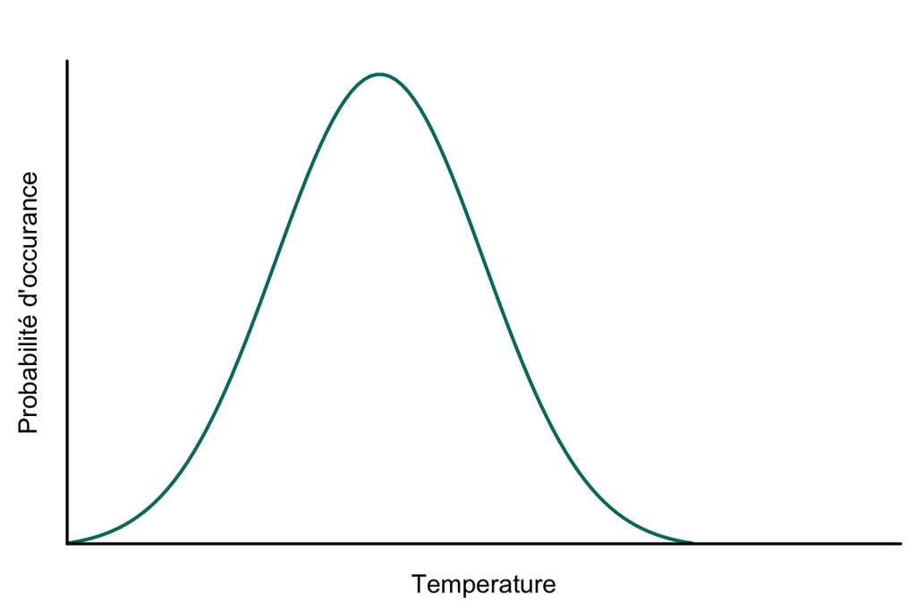

lien établi -> prédiction !

## Modèles phénoménologiques

**Quelle est la corrélation entre le climat et la distribution des espèces ?**

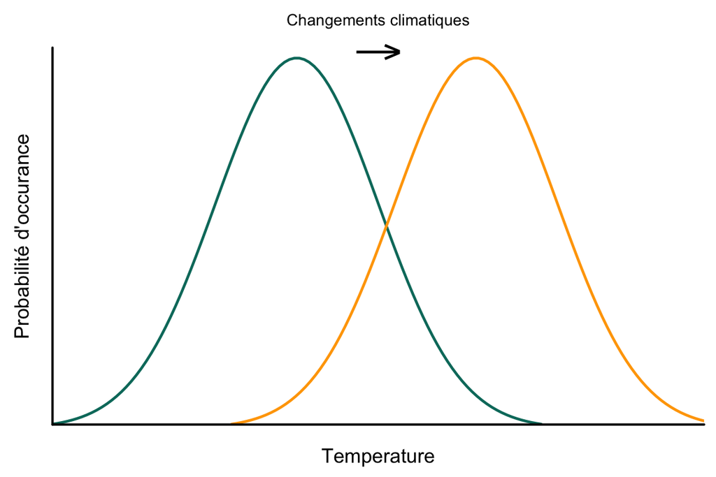

## Modèles phénoménologiques

Distribution de l'érable à sucre dans 100 ans

[figure not shown]

*Croyez-vous qu'elle peut le faire ?*

Quelles sont vos prédictions sur ce qu'il faut arriver pour que la forêt temperée émigre vers la forêt boréale ?

[figure not shown]

# Un modèle plus mécanistique

## Les états

- **Boréale**
  - *Picea mariana, Picea glauca, Picea rubens, Larix laricina, Pinus banksiana, Abies balsamea, and Thuja occidentalis*
- **Tempérée**
  - *Prunus serotina, Acer rubrum, Acer saccharum, Fraxinus americana, Fraxinus nigra, Fagus gran- difolia, Ostrya virginiana, Tilia americana*
- **Mixte de boréale et tempérée** (écotone)
  - si les deux catégories d'espèces sont présent
- **Régeneration**
  - Surface terrier < 5 m²/ha

## Le modèle

4 processus écologiques

[figure not shown]

## Le modèle

4 processus écologiques
- Pertubation

[figure not shown]

## Le modèle

4 processus écologiques
- Pertubation
- Succession

[figure not shown]

## Le modèle

4 processus écologiques
- Pertubation
- Succession
- Colonisation

[figure not shown]

## Le modèle

4 processus écologiques
- Pertubation
- Succession
- Colonisation
- Exclusion competitive

[figure not shown]

## Le modèle

[figure not shown]

## Le modèle

Des processus dépendant de la
- Temperature
- Precipitation
- Abundance des états

[figure not shown]

## Le modèle - une simulation

[figure not shown]

## Le modèle - résultat climat actuelle

*Représente-t-il bien la relation entre le climat et la distribution des espèces ?*

[figure not shown]

## Le modèle - simulation avec changement climatique

C'est quoi l'effet de l'augumentation de la temperature sur la distribution des états ?

[figure not shown]

## Résultats

[figure not shown]

- *Quelles sont les conséquences de ce délai ?*

- *Et qu'est-ce qu'on peut faire dans ce cas ?*

# L'aménagement forestier peut-il augmenter le taux de migration vers le nord ?

## Plan de géstion

[figure not shown]

## Pratiques d'aménagement forestier

Coupe rase

[figure not shown]

## Pratiques d'aménagement forestier

Plantation

[figure not shown]

## Pratiques d'aménagement forestier

Éclaircie

[figure not shown]

## Pratiques d'aménagement forestier

plantation d'enrichissement

[figure not shown]

*Comment intégrer ces pratiques au modèle théorique des états ?*

## Éclaircie ou pertubation naturelle ?

[figure not shown]

## Modèle + amenagement foresiter

Relier les processus du modèle avec les pratiques d'aménagement forestier

[figure not shown]

## Le modèle - simulation avec changement climatique

**Sans** aménagement forestier

[figure not shown]

**Avec** aménagement forestier

[figure not shown]

## Résultats - plantation

**Sans** aménagement forestier

[figure not shown]

**Avec** aménagement forestier

[figure not shown]

## Résultats - coupe rase

**Sans** aménagement forestier

[figure not shown]

**Avec** aménagement forestier

[figure not shown]

## Résultats - éclaircie

**Sans** aménagement forestier

[figure not shown]

**Avec** aménagement forestier

[figure not shown]

## Résultats - plantation d'enrichissement

**Sans** aménagement forestier

[figure not shown]

**Avec** aménagement forestier

[figure not shown]